# Project 6: Data Exploration and Visualization

### Overview

In this project, you will apply data exploration and visualization techniques to a real-world dataset of your choice. You'll practice using pandas for data analysis and create meaningful visualizations to gain insights from your data. This project builds on your Python programming skills while introducing you to the exciting world of data science.

In [Lab6](https://colab.research.google.com/drive/1WxHaCZlN8d0kVgTCBmbMWmF29TM4pDJs?usp=sharing), you explore the titanic dataset and you should use it as a sample and pick a dataset of your interest to do a similar data exploration and visualization.

### Project Objectives

- Find and select a dataset from a real-world data source
- Formulate a clear inquiry question based on your chosen dataset
- Perform exploratory data analysis using pandas functions
- Create at least two meaningful data visualizations
- Analyze your findings and answer your inquiry question
- Reflect on the insights gained through data exploration

### Data Sources

You can choose from various online data sources such as:

- [Kaggle](https://www.kaggle.com/datasets) - Wide variety of datasets
- [data.gov](https://www.data.gov/) - U.S. government data
- [Our World in Data](https://ourworldindata.org/) - Global development data
- [GitHub](https://github.com/datasets) - Curated datasets
- [Google Dataset Search](https://datasetsearch.research.google.com/) - Search for datasets
- Or any other reliable data source you find interesting

## Part 1: Dataset Selection and Initial Exploration

#### TODO Tasks:

1. Select Your Dataset: Choose a dataset that interests you. Make sure it has at least 100 rows and multiple columns with different data types (e.g., numerical, categorical, dates).

Please create either text or code cells in between the TODO tasks to do the work.

```python
# I chose "Video Game Sales with Ratings" as my dataset: https://www.kaggle.com/datasets/rush4ratio/video-game-sales-with-ratings
```

2. Import Libraries: Import the necessary libraries (pandas, matplotlib, seaborn) at the beginning of your notebook by creating code cells below this text cell.

```python
!pip install pandas==2.2.2
!pip install seaborn==0.13.2

import pandas as pd
from matplotlib import pyplot as plt
import seaborn as sns
```

3. Load Your Data: Load your chosen dataset using pandas and save it to a pandas dataframe. Please create a code cell below this text cell to do it.

```python
# Install dependencies as needed:
# pip install kagglehub[pandas-datasets]
import kagglehub
from kagglehub import KaggleDatasetAdapter

# Set the path to the file you'd like to load
file_path = "Video_Games_Sales_as_at_22_Dec_2016.csv"

# Load the latest version
df = kagglehub.load_dataset(
  KaggleDatasetAdapter.PANDAS,
  "rush4ratio/video-game-sales-with-ratings",
  file_path,
)

print("First 5 records:", df.head())
```

```
Extracting zip of Video_Games_Sales_as_at_22_Dec_2016.csv...
```

```
First 5 records:                        Name Platform  Year_of_Release         Genre Publisher  \
0                Wii Sports      Wii           2006.0        Sports  Nintendo
1         Super Mario Bros.      NES           1985.0      Platform  Nintendo
2            Mario Kart Wii      Wii           2008.0        Racing  Nintendo
3         Wii Sports Resort      Wii           2009.0        Sports  Nintendo
4  Pokemon Red/Pokemon Blue       GB           1996.0  Role-Playing  Nintendo

   NA_Sales  EU_Sales  JP_Sales  Other_Sales  Global_Sales  Critic_Score  \
0     41.36     28.96      3.77         8.45         82.53          76.0
1     29.08      3.58      6.81         0.77         40.24           NaN
2     15.68     12.76      3.79         3.29         35.52          82.0
3     15.61     10.93      3.28         2.95         32.77          80.0
4     11.27      8.89     10.22         1.00         31.37           NaN

   Critic_Count User_Score  User_Count Developer Rating
0          51.0          8       322.0  Nintendo      E
1           NaN        NaN         NaN       NaN    NaN
2          73.0        8.3       709.0  Nintendo      E
3          73.0          8       192.0  Nintendo      E
4           NaN        NaN         NaN       NaN    NaN
```

```python
print("\n--- Statistical Summary ---\n")
df.describe()
```

```
--- Statistical Summary ---
```

|  | Year_of_Release | NA_Sales | EU_Sales | JP_Sales | Other_Sales | Global_Sales | Critic_Score | Critic_Count | User_Count |
| --- | --- | --- | --- | --- | --- | --- | --- | --- | --- |
| count | 16450.000000 | 16719.000000 | 16719.000000 | 16719.000000 | 16719.000000 | 16719.000000 | 8137.000000 | 8137.000000 | 7590.000000 |
| mean | 2006.487356 | 0.263330 | 0.145025 | 0.077602 | 0.047332 | 0.533543 | 68.967679 | 26.360821 | 162.229908 |
| std | 5.878995 | 0.813514 | 0.503283 | 0.308818 | 0.186710 | 1.547935 | 13.938165 | 18.980495 | 561.282326 |
| min | 1980.000000 | 0.000000 | 0.000000 | 0.000000 | 0.000000 | 0.010000 | 13.000000 | 3.000000 | 4.000000 |
| 25% | 2003.000000 | 0.000000 | 0.000000 | 0.000000 | 0.000000 | 0.060000 | 60.000000 | 12.000000 | 10.000000 |
| 50% | 2007.000000 | 0.080000 | 0.020000 | 0.000000 | 0.010000 | 0.170000 | 71.000000 | 21.000000 | 24.000000 |
| 75% | 2010.000000 | 0.240000 | 0.110000 | 0.040000 | 0.030000 | 0.470000 | 79.000000 | 36.000000 | 81.000000 |
| max | 2020.000000 | 41.360000 | 28.960000 | 10.220000 | 10.570000 | 82.530000 | 98.000000 | 113.000000 | 10665.000000 |

```python
print("\n--- Column Names ---\n")
print(df.columns)
```

```
--- Column Names ---

Index(['Name', 'Platform', 'Year_of_Release', 'Genre', 'Publisher', 'NA_Sales',
       'EU_Sales', 'JP_Sales', 'Other_Sales', 'Global_Sales', 'Critic_Score',
       'Critic_Count', 'User_Score', 'User_Count', 'Developer', 'Rating'],
      dtype='object')
```

4. Data Summary: Use the following functions to do inital exploration your dataset:
- info() - Display information about the dataset structure
- describe() - Show statistical summary of numerical columns
- head() - Display the first 5 rows (df.head())
- shape - Show the dimensions of the dataset (e.g. df.shape)
- columns - Get the column names (e.g. df.columns)

You may use 5 code cells below this text cell to accomplish it.

```python
print("\n--- DataFrame Info ---\n")
df.info()

print("\n--- First 5 Rows ---\n")
print(df.head())

print("\n--- DataFrame Shape ---\n")
print(df.shape)
```

```
--- DataFrame Info ---

<class 'pandas.core.frame.DataFrame'>
RangeIndex: 16719 entries, 0 to 16718
Data columns (total 16 columns):
 #   Column           Non-Null Count  Dtype
---  ------           --------------  -----
 0   Name             16717 non-null  object
 1   Platform         16719 non-null  object
 2   Year_of_Release  16450 non-null  float64
 3   Genre            16717 non-null  object
 4   Publisher        16665 non-null  object
 5   NA_Sales         16719 non-null  float64
 6   EU_Sales         16719 non-null  float64
 7   JP_Sales         16719 non-null  float64
 8   Other_Sales      16719 non-null  float64
 9   Global_Sales     16719 non-null  float64
 10  Critic_Score     8137 non-null   float64
 11  Critic_Count     8137 non-null   float64
 12  User_Score       10015 non-null  object
 13  User_Count       7590 non-null   float64
 14  Developer        10096 non-null  object
 15  Rating           9950 non-null   object
dtypes: float64(9), object(7)
memory usage: 2.0+ MB

--- First 5 Rows ---

                       Name Platform  Year_of_Release         Genre Publisher  \
0                Wii Sports      Wii           2006.0        Sports  Nintendo
1         Super Mario Bros.      NES           1985.0      Platform  Nintendo
2            Mario Kart Wii      Wii           2008.0        Racing  Nintendo
3         Wii Sports Resort      Wii           2009.0        Sports  Nintendo
4  Pokemon Red/Pokemon Blue       GB           1996.0  Role-Playing  Nintendo

   NA_Sales  EU_Sales  JP_Sales  Other_Sales  Global_Sales  Critic_Score  \
0     41.36     28.96      3.77         8.45         82.53          76.0
1     29.08      3.58      6.81         0.77         40.24           NaN
2     15.68     12.76      3.79         3.29         35.52          82.0
3     15.61     10.93      3.28         2.95         32.77          80.0
4     11.27      8.89     10.22         1.00         31.37           NaN

   Critic_Count User_Score  User_Count Developer Rating
0          51.0          8       322.0  Nintendo      E
1           NaN        NaN         NaN       NaN    NaN
2          73.0        8.3       709.0  Nintendo      E
3          73.0          8       192.0  Nintendo      E
4           NaN        NaN         NaN       NaN    NaN

--- DataFrame Shape ---

(16719, 16)
```

5. Inquiry Question: Write a clear, specific question that you want to answer using your dataset by creating a text cell below and **write the question in bold please.**

For example:

- "How has the average temperature changed in major cities over the past decade?"
- "What factors are most strongly correlated with housing prices?"
- "Is there a relationship between education level and income?"

**Inquiry Question: "Do video game sales correlate to the quality of the game?"**

## Part 2: Data Visualization and Analysis

#### TODO Tasks:

1. Data Cleaning (if necessary): Check for and handle any missing values, duplicates, or data quality issues.

**NOTE: This could be a daunting task even for seasoned data scientists. My suggestion is to use a dataset that is already clean if you can for the purpose of completing this assignment in a week.**

```python
# Initial DataFrame check (after previous specific cleaning)
print("--- Initial State of DataFrame for General Cleaning ---")
print("DataFrame shape:", df.shape)
print("\n--- Missing Values Before General Cleaning ---")
print(df.isnull().sum())

# 1. Removing duplicate rows
initial_rows = df.shape[0]
df.drop_duplicates(inplace=True)
rows_dropped_duplicates = initial_rows - df.shape[0]
print(f"\n--- After Removing Duplicates ---")
print(f"Rows dropped due to duplicates: {rows_dropped_duplicates}")
print("DataFrame shape:", df.shape)

# 2. Dropping columns with all missing values
initial_cols = df.shape[1]
df.dropna(axis=1, how='all', inplace=True)
cols_dropped = initial_cols - df.shape[1]
print(f"\n--- After Dropping Columns with All NaNs ---")
print(f"Columns dropped due to all NaNs: {cols_dropped}")
print("DataFrame shape:", df.shape)

# 3. Dropping rows with any missing values
initial_rows_before_any_nan_drop = df.shape[0]
df.dropna(inplace=True)
rows_dropped_any_nan = initial_rows_before_any_nan_drop - df.shape[0]
print(f"\n--- After Dropping Rows with Any NaNs ---")
print(f"Rows dropped due to any NaNs: {rows_dropped_any_nan}")
print("DataFrame shape:", df.shape)

# 4. Final check for missing values
print("\n--- Missing Values After General Cleaning ---")
print(df.isnull().sum())
```

```
--- Initial State of DataFrame for General Cleaning ---
DataFrame shape: (16719, 16)

--- Missing Values Before General Cleaning ---
Name                  2
Platform              0
Year_of_Release     269
Genre                 2
Publisher            54
NA_Sales              0
EU_Sales              0
JP_Sales              0
Other_Sales           0
Global_Sales          0
Critic_Score       8582
Critic_Count       8582
User_Score         6704
User_Count         9129
Developer          6623
Rating             6769
dtype: int64

--- After Removing Duplicates ---
Rows dropped due to duplicates: 0
DataFrame shape: (16719, 16)

--- After Dropping Columns with All NaNs ---
Columns dropped due to all NaNs: 0
DataFrame shape: (16719, 16)

--- After Dropping Rows with Any NaNs ---
Rows dropped due to any NaNs: 9894
DataFrame shape: (6825, 16)

--- Missing Values After General Cleaning ---
Name               0
Platform           0
Year_of_Release    0
Genre              0
Publisher          0
NA_Sales           0
EU_Sales           0
JP_Sales           0
Other_Sales        0
Global_Sales       0
Critic_Score       0
Critic_Count       0
User_Score         0
User_Count         0
Developer          0
Rating             0
dtype: int64
```

Examples:

- Checking for missing values: df.isnull().sum()
- Dropping rows with any missing values: df.dropna(inplace=True)
- Dropping columns with all missing values: df.dropna(axis=1, how='all', inplace=True)
- Removing duplicate row: df.drop_duplicates(inplace=True)
2. Create Visualizations: Create at least 2 different types of visualizations that help answer your research question. Choose from:
- Bar charts
- Line plots
- Scatter plots
- Histograms
- Box plots
- Heatmaps
- Any other appropriate visualization

I choose: A) A set of scatter plots showing sales on the y-axis and review scores on the x-axis. One graph will be user scores, one will be critic scores. And we'll ask it to do a regression line.

B) Categorize the games by quality in 4 bins, then make box and whisker plots for each of the bins to compare the spread and average for each. AI decided we should use a logarithmic scale to make the charts more readable.

3. Customize Your Plots: Make sure your visualizations are clear and informative by:
- Adding appropriate titles
- Labeling axes
- Using colors effectively
- Adding legends when necessary

Please create code cells below this to create your visualizations.

```
Correlation between Global Sales and Critic Score: 0.24
Correlation between Global Sales and User Score: 0.09
```

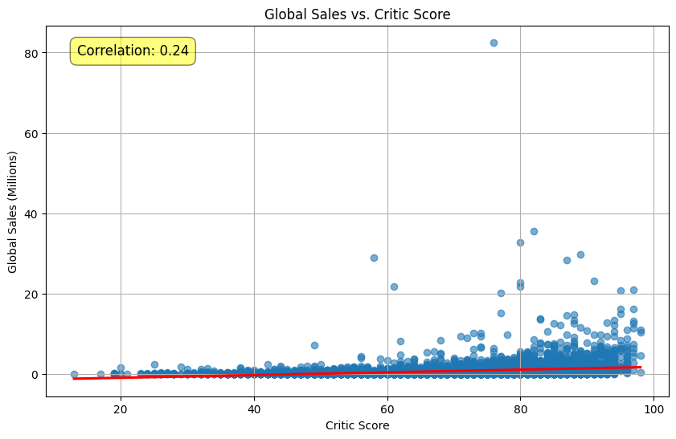

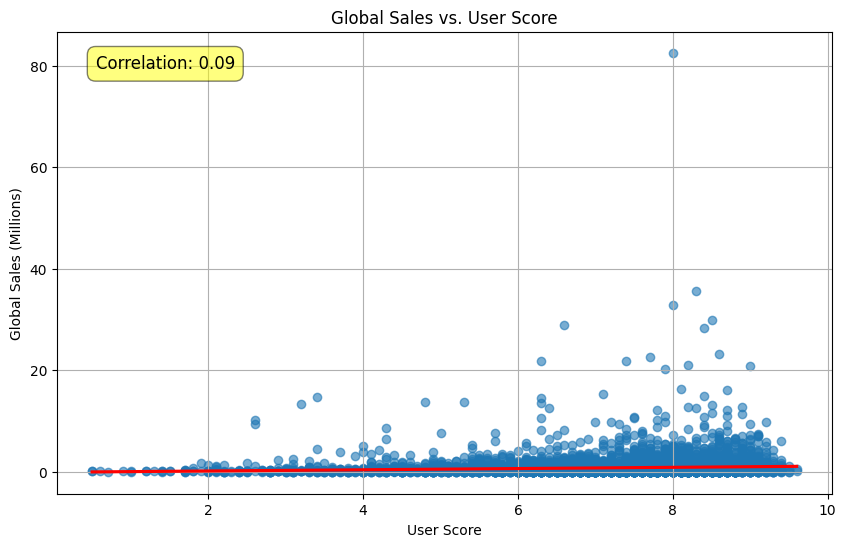

```python
# Ensure User_Score is numeric before calculating correlation and plotting
df['User_Score'] = pd.to_numeric(df['User_Score'], errors='coerce')
df.dropna(subset=['User_Score'], inplace=True) # Drop rows where conversion failed (e.g., 'tbd' became NaN)

# Calculate correlation coefficients
correlation_critic = df['Global_Sales'].corr(df['Critic_Score'])
correlation_user = df['Global_Sales'].corr(df['User_Score'])

print(f"Correlation between Global Sales and Critic Score: {correlation_critic:.2f}")
print(f"Correlation between Global Sales and User Score: {correlation_user:.2f}")

# Scatter plot with regression line: Global Sales vs. Critic Score
plt.figure(figsize=(10, 6))
sns.regplot(data=df, x='Critic_Score', y='Global_Sales', scatter_kws={'alpha':0.6}, line_kws={'color':'red'})
plt.title('Global Sales vs. Critic Score')
plt.xlabel('Critic Score')
plt.ylabel('Global Sales (Millions)')
plt.grid(True)
# Add correlation coefficient to the plot
plt.text(0.05, 0.95, f'Correlation: {correlation_critic:.2f}', transform=plt.gca().transAxes, fontsize=12, verticalalignment='top', bbox=dict(boxstyle='round,pad=0.5', fc='yellow', alpha=0.5))
plt.show()

# Scatter plot with regression line: Global Sales vs. User Score
plt.figure(figsize=(10, 6))
sns.regplot(data=df, x='User_Score', y='Global_Sales', scatter_kws={'alpha':0.6}, line_kws={'color':'red'})
plt.title('Global Sales vs. User Score')
plt.xlabel('User Score')
plt.ylabel('Global Sales (Millions)')
plt.grid(True)
# Add correlation coefficient to the plot
plt.text(0.05, 0.95, f'Correlation: {correlation_user:.2f}', transform=plt.gca().transAxes, fontsize=12, verticalalignment='top', bbox=dict(boxstyle='round,pad=0.5', fc='yellow', alpha=0.5))
plt.show()
```

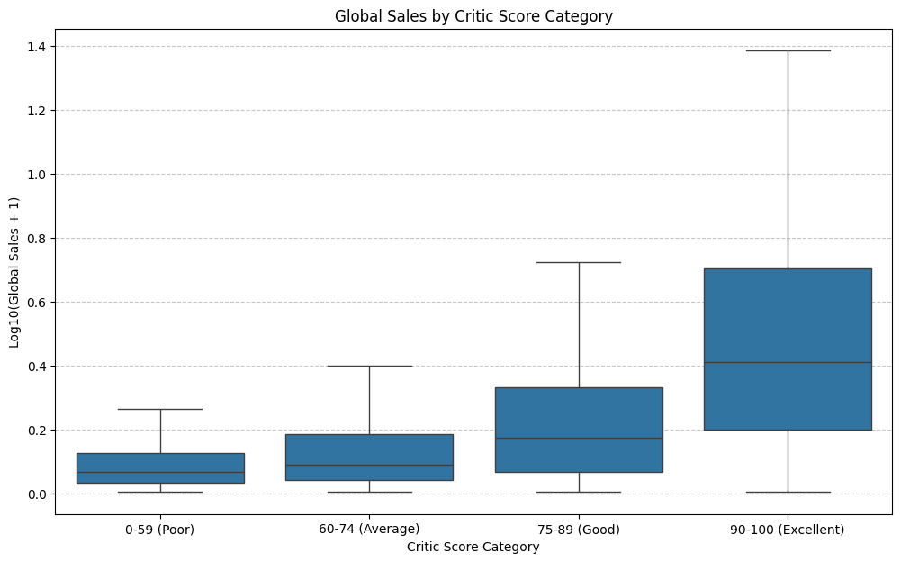

```python
import numpy as np

# Define bins and labels for Score_Category
bins = [0, 59, 74, 89, 100]
labels = ['0-59 (Poor)', '60-74 (Average)', '75-89 (Good)', '90-100 (Excellent)']

# Create the Score_Category column
df['Score_Category'] = pd.cut(df['Critic_Score'], bins=bins, labels=labels, right=True, include_lowest=True)

# Log-transform Global_Sales for better interpretability
df['Log10_Global_Sales'] = np.log10(df['Global_Sales'] + 1)

# Create the box plot
plt.figure(figsize=(12, 7))
sns.boxplot(x='Score_Category', y='Log10_Global_Sales', data=df, order=labels, showfliers=False)
plt.title('Global Sales by Critic Score Category')
plt.xlabel('Critic Score Category')
plt.ylabel('Log10(Global Sales + 1)')
plt.grid(axis='y', linestyle='--', alpha=0.7)
plt.show()
```

4. Analysis: Write 1-2 paragraphs discussing:
- Whether your research question can be answered with the available data
- What insights you discovered through your visualizations
- Any unexpected or interesting findings
- Limitations of your analysis
- Suggestions for further investigation

Please create a text cell below this cell to write your analysis.

My question can somewhat be answered by the available data. The trendlines do have an upward slope, so that's a good start. There is weak correlation with sales and critic score, but for user score it doesn't even qualify as weak. The box plot, though, sure makes it look like the sales get very clearly higher with better review categories. An insight I discovered was that the better reviewed games each have a get more and more spread out based on the box and whisker plot. This wouldn't be due to outliers, as even the quartiles clearly get more spread out as we move rightward.

An unexpected finding was how weak the correlation was for reviews and sales. I expected it to be strong, with the notion that better reviewed games get more hype and, thus, more people are interested in them. I wonder if my analysis is limited by the games that have very few reviews. Metacritic uses the mean of reviews for its rating, and if only three people have given a game a review then it could be heavily skewed. For further investigation, I would trim this bulky dataset even more than I already did. I cleaned out games with null data, but I think if we just trimmed that to the top 1,000 games we might have better data. Or if we could figure out a way to get rid of games that don't have enough reviews to get a good grasp of its quality. Also, the scatterplots are terrible and useless with all that data. It's just a big blob at the bottom.